# The Exchange Rate of the Japanese Yen and the United States Dollar Pre SARS-CoV-2 vs. During SARS-CoV-2

Kizuku Miyashita & Cameron Lee

4/29/2022

## Abstract

In the study we conducted, we wanted to see if there was a correlation between the value of the Japanese Yen’s exchange rate with the United States dollar before the SARS-CoV-2 virus became a worldwide pandemic and its current value as the pandemic is ongoing.

## SARS-CoV-2 Trends In Japan

Here is a graph representing the number of monthly Japan has had since 2020.

```r
library(xlsx)
```

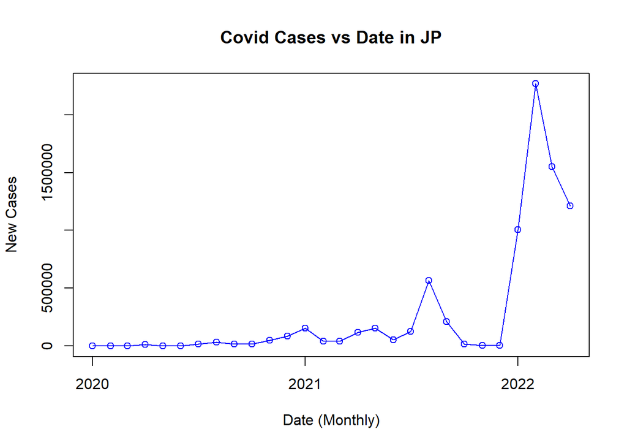

```r
dataJ = read.xlsx("JapanCovidTrends.xlsx",sheetIndex = 1, header = T)
monthJ = dataJ[,1]
caseJ = dataJ[,2]
plot(monthJ,caseJ,main="Covid Cases vs Date in JP",
     xlab = "Date (Monthly)",ylab="New Cases",
     type = "o", col='blue')
```

The graph details a significant number of cases in Japan during this worldwide pandemic.

## SARS-CoV-2 Trends in the United States

```r
dataUSA = read.xlsx("USACovidTrends.xlsx",sheetIndex = 1, header = T)
dataUSA
```

```
##          Date     Cases
## 1  2020-01-01      0.03
## 2  2020-02-01      0.66
## 3  2020-03-01   2123.73
## 4  2020-04-01  18453.58
## 5  2020-05-01   7441.02
## 6  2020-06-01   8608.61
## 7  2020-07-01  19383.07
## 8  2020-08-01  14767.73
## 9  2020-09-01  12196.06
## 10 2020-10-01  19351.47
## 11 2020-11-01  44322.12
## 12 2020-12-01  63705.21
## 13 2021-01-01  60859.90
## 14 2021-02-01  23426.87
## 15 2021-03-01  17961.54
## 16 2021-04-01  18453.58
## 17 2021-05-01   8988.67
## 18 2021-06-01   3933.28
## 19 2021-07-01  13817.88
## 20 2021-08-01  42574.07
## 21 2021-09-01  41114.75
## 22 2021-10-01  24436.57
## 23 2021-11-01  44322.12
## 24 2021-12-01  63790.72
## 25 2022-01-01 202293.40
## 26 2022-02-01  37383.35
## 27 2022-03-01   9452.05
## 28 2022-04-01  10434.58
```

```r
monthUSA = dataUSA[,1]
caseUSA = dataUSA[,2]
summary(caseUSA)
```

```
##      Min.   1st Qu.    Median      Mean   3rd Qu.      Max.
##      0.03   9336.20  18453.58  29771.31  41479.58 202293.40
```

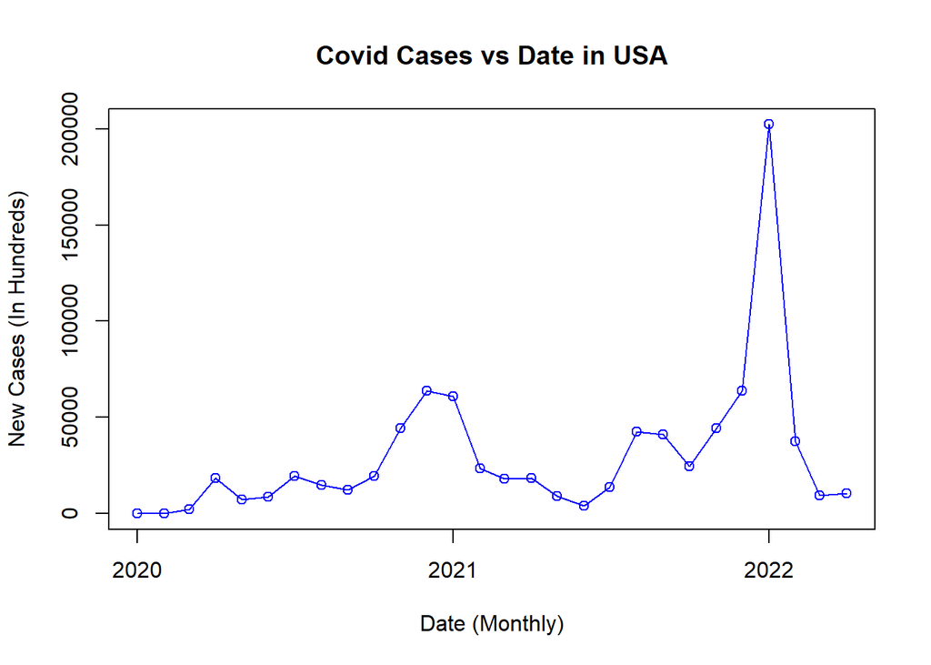

```r
plot(monthUSA,caseUSA,main="Covid Cases vs Date in USA",
     xlab = "Date (Monthly)",ylab="New Cases (In Hundreds)",
     type = "o", col='blue')
```

As you can see, there is a much larger spike in the number of cases in the United States.

## Hypothesis Testing

Due to the economic turmoil that the SARS-CoV-2 virus caused, it could be assumed that the monetary value of the Yen, when exchanged with the U.S. Dollar, had a higher value prior to the illness spreading globally.

To test our hypothesis, we conducted three pooled-t tests. As both data sets that we collected had almost equal standard deviations, we could go forward with this test.

**Significant Note: The lesser the numeric value of the Yen, the higher the value when exchanged with the United States Dollar**

### Two-Tailed Pooled T-Test

First, we performed a two-tailed pooled t-test to decide whether or not there was sufficient enough data to reject the claim that the exchange rate from both time periods were equal.

Here is our code:

```r
data = read.xlsx("ExchangeRateData.xlsx",sheetIndex = 1, header = T)
data
```

```
##    observation_date   EXJPUS
## 1        2017-01-01 114.8721
## 2        2017-02-01 112.9116
## 3        2017-03-01 112.9165
## 4        2017-04-01 110.0910
## 5        2017-05-01 112.2436
## 6        2017-06-01 110.9141
## 7        2017-07-01 112.4170
## 8        2017-08-01 109.8270
## 9        2017-09-01 110.7760
## 10       2017-10-01 112.9148
## 11       2017-11-01 112.8190
## 12       2017-12-01 112.9405
## 13       2018-01-01 110.8710
## 14       2018-02-01 107.9700
```

[output cut: 49 more lines]

```r
monPreCOVID = data[seq(1,36), 1]
monPreCOVID
```

```
##  [1] "2017-01-01" "2017-02-01" "2017-03-01" "2017-04-01" "2017-05-01"
##  [6] "2017-06-01" "2017-07-01" "2017-08-01" "2017-09-01" "2017-10-01"
## [11] "2017-11-01" "2017-12-01" "2018-01-01" "2018-02-01" "2018-03-01"
## [16] "2018-04-01" "2018-05-01" "2018-06-01" "2018-07-01" "2018-08-01"
## [21] "2018-09-01" "2018-10-01" "2018-11-01" "2018-12-01" "2019-01-01"
## [26] "2019-02-01" "2019-03-01" "2019-04-01" "2019-05-01" "2019-06-01"
## [31] "2019-07-01" "2019-08-01" "2019-09-01" "2019-10-01" "2019-11-01"
## [36] "2019-12-01"
```

```r
monDurCOVID = data[seq(37,63),1]
preCOVID = data[seq(1,36), 2]
preCOVID
```

```
##  [1] 114.8721 112.9116 112.9165 110.0910 112.2436 110.9141 112.4170 109.8270
##  [9] 110.7760 112.9148 112.8190 112.9405 110.8710 107.9700 106.0468 107.6562
## [17] 109.6882 110.0638 111.5210 110.9965 112.0974 112.7218 113.3380 112.1994
## [25] 108.9605 110.4400 111.1443 111.6414 109.9714 108.0685 108.2864 106.1886
## [33] 107.5400 108.1368 108.8579 109.1010
```

```r
duringCOVID = data[seq(37,63),2]
t.test(preCOVID, duringCOVID, mu = 0, var.equal = T, alternative = "two.sided", conf.level = 0.95)
```

```
##
##  Two Sample t-test
##
## data:  preCOVID and duringCOVID
## t = 1.8271, df = 61, p-value = 0.07258
## alternative hypothesis: true difference in means is not equal to 0
## 95 percent confidence interval:
##  -0.1302258  2.8881943
## sample estimates:
## mean of x mean of y
##  110.5319  109.1530
```

```r
p = 0.07258
```

In this study, we assumed that the average exchange rate from pre-covid times compared covid times were not equal. Since p = 0.07258, it is greater than 0.05 which means we cannot reject the claim that the null hypothesis are equal to each other.

Although we cannot reject the null hypothesis, our p-value provides us with insight that we may be able to use another t-test to see what time period had the greater exchange rate value. This is because p is near our rejection value of 0.05 for our data.

Due to the results of our first test, we must do a right-tailed and left-tailed pooled t-test as we are unable to reject null hypothesis.

### Left-Tailed Pooled T-Test

Here is our code:

```r
t.test(preCOVID, duringCOVID, mu = 0, var.equal = T, alternative = "less", conf.level = 0.95)
```

```
##
##  Two Sample t-test
##
## data:  preCOVID and duringCOVID
## t = 1.8271, df = 61, p-value = 0.9637
## alternative hypothesis: true difference in means is less than 0
## 95 percent confidence interval:
##      -Inf 2.639577
## sample estimates:
## mean of x mean of y
##  110.5319  109.1530
```

```r
p = 0.9637
```

### Right-Tailed Pooled T-Test

Lastly, we decided to construct a right-tailed pooled t-test to rule out the idea that we can reject the null hypothesis.

Here is our code:

```r
t.test(preCOVID, duringCOVID, mu = 0, var.equal = T, alternative = "greater", conf.level = 0.95)
```

```
##
##  Two Sample t-test
##
## data:  preCOVID and duringCOVID
## t = 1.8271, df = 61, p-value = 0.03629
## alternative hypothesis: true difference in means is greater than 0
## 95 percent confidence interval:
##  0.118391      Inf
## sample estimates:
## mean of x mean of y
##  110.5319  109.1530
```

```r
p = 0.03629
```

In this study, we assumed that the average exchange rate from pre-covid times were less compared to covid times. Since p = 0.03629, it is less than 0.05 which means we can reject the null hypothesis.

With 95% confidence, the Japanese Yen’s numeric value is greater during pre-covid times compared to present day covid times. Ultimately, this means that the exchange rate was less during before covid started when comparing it to the present exchange rates.

## Conclusion

We can conclude from our last t-test that the value of the Japanese Yen has been greater during covid times when being compared to pre-covid times. Although it was assumed that the value of the Yen would be greater during non-covid times, it has been proven false and remains in a more positive state. Our original assumption was proven untrue.

## Predictions For Future Exchange Rate Values

### Pre-Covid and During Covid Exchange Rates

Before getting into our predictions for the January of 2024, here are the graphs describing the exchange rates before the pandemic and during the pandemic.

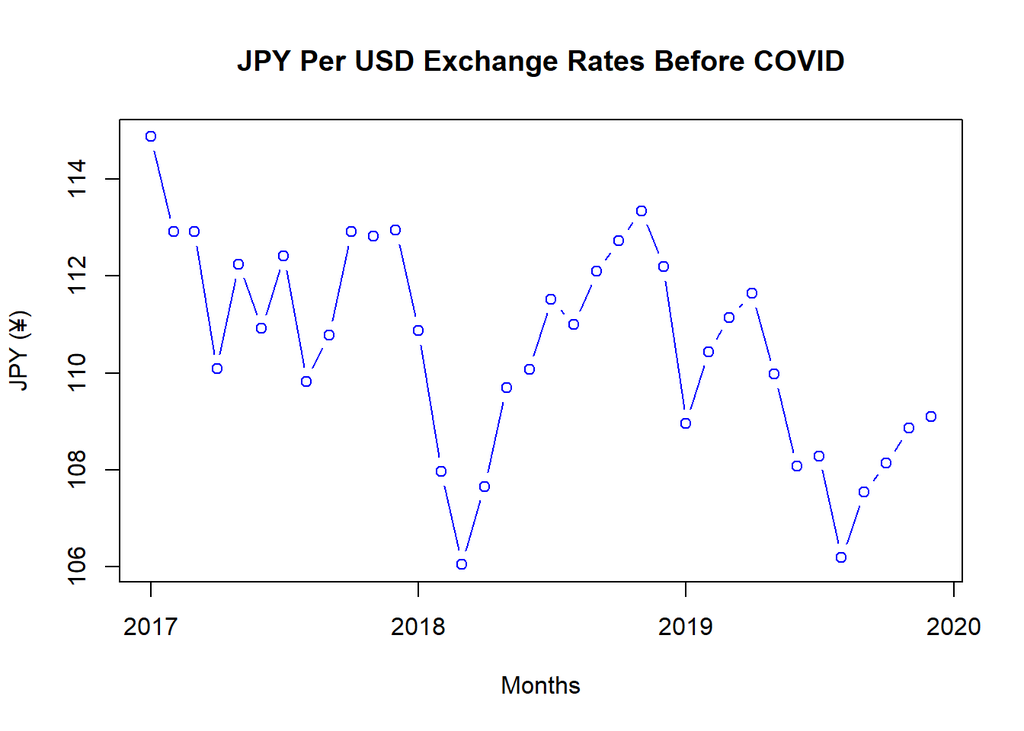

```r
plot(monPreCOVID, preCOVID, main = "JPY Per USD Exchange Rates Before COVID", xlab = "Months",
     ylab = "JPY (¥)", col = "Blue", type = "b")
```

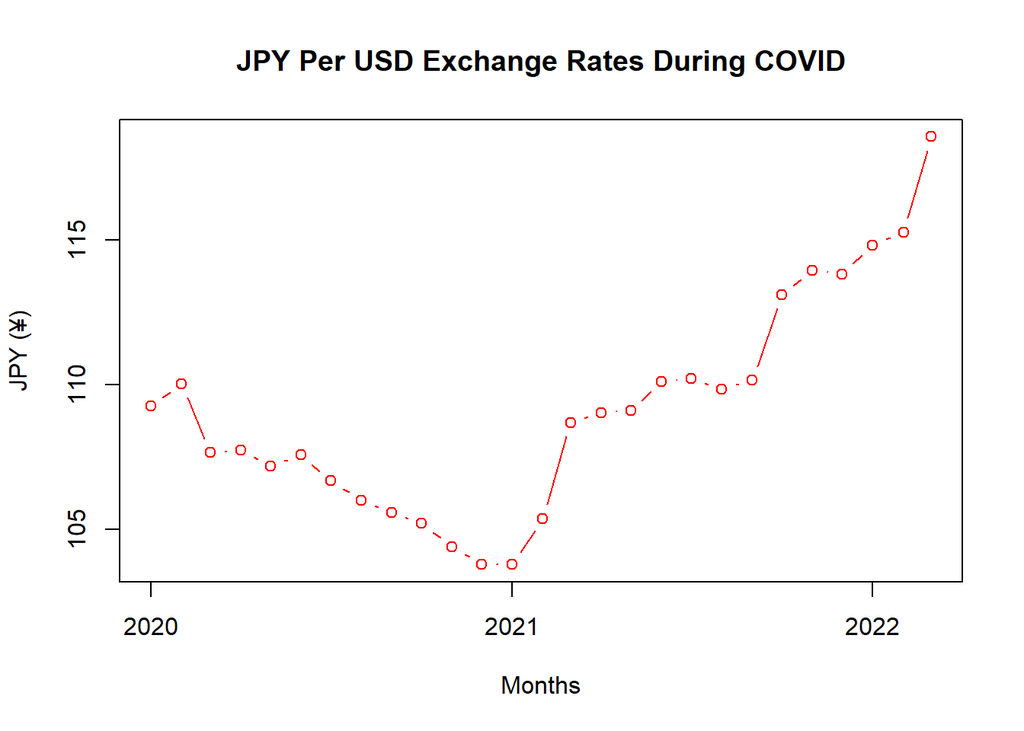

```r
#During-Covid Exchange Rates
plot(monDurCOVID,duringCOVID, main = "JPY Per USD Exchange Rates During COVID", xlab = "Months",
     ylab = "JPY (¥)", col = "Red", type = "b")
```

As you can see from the 2017-2020 graph, there is a very unstable exchange rate between the Japanese Yen and the United States dollar. Every month there is a rapid fluctuation or decrease in the value of the Yen.

The 2020-2022 year graph provides evidence there is a clear increase in value at the start of COVID and then a tremendous decrease of value that continues to reflect the present day value.

### Linear Regression to Predict January of 2024

As we looked at the data we contained, we disregarded any data before 2021 as it was not current and did not allow for us to make a proper linear regression line.

Using the data from 2021-present, we had to make sure that there was no identifiable residual pattern and confirm that the data follows a normal line.

We checked to see if these requirements were true by using a matrix plot of the linear regression line that we created.

Here is our code:

```r
x_date = c(0:14)
y_exchange = data[seq(49,63,1),2]

m = lm(formula = y_exchange~x_date)
summary(m)
```

```
##
## Call:
## lm(formula = y_exchange ~ x_date)
##
## Residuals:
##      Min       1Q   Median       3Q      Max
## -1.73567 -0.73683 -0.01639  0.62844  1.80036
##
## Coefficients:
##              Estimate Std. Error t value Pr(>|t|)
## (Intercept) 105.23276    0.56300  186.92  < 2e-16 ***
## x_date        0.83299    0.06844   12.17 1.76e-08 ***
## ---
## Signif. codes:  0 '***' 0.001 '**' 0.01 '*' 0.05 '.' 0.1 ' ' 1
##
## Residual standard error: 1.145 on 13 degrees of freedom
## Multiple R-squared:  0.9193, Adjusted R-squared:  0.9131
## F-statistic: 148.1 on 1 and 13 DF,  p-value: 1.763e-08
```

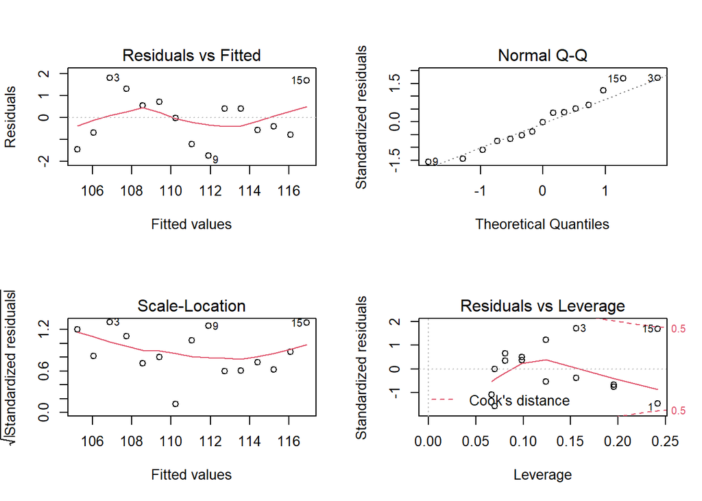

```r
#checking if it's okay to use linear regression.
layout(matrix(data=1:4,nrow=2,ncol=2,byrow=T))
plot(m)
```

```r
layout(matrix(data=1,nrow=1,ncol=1))#reset
```

The top two graphs are the ones that we mainly focused on.

```r
y.intercept=m$coefficients[1]
slope=m$coefficients[2]
cat("y-intercept = ", y.intercept,"\t","slope = ", slope, "\n")
```

```
## y-intercept =  105.2328   slope =  0.8329886
```

```r
cat("The regression equation: $1 = ",y.intercept," + (",slope,") * Number_of_months (JPY)\n")
```

```
## The regression equation: $1 =  105.2328  + ( 0.8329886 ) * Number_of_months (JPY)
```

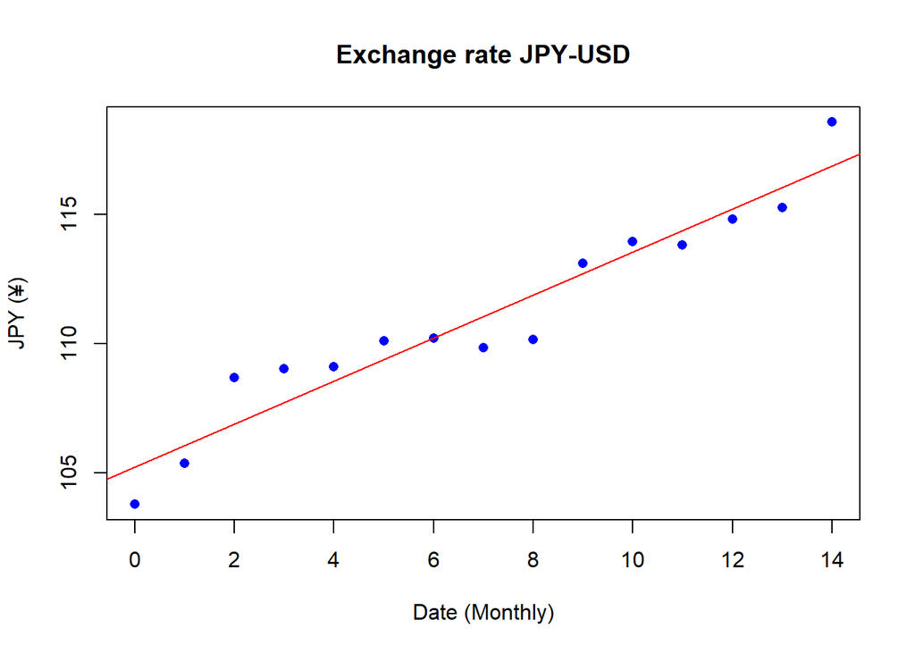

```r
#Plotting
plot(x_date,y_exchange,main="Exchange rate JPY-USD",
     xlab = "Date (Monthly)",ylab="JPY (¥)",
     pch = 16,col='blue')
abline(reg = m,col="red")
```

```r
#2024
cat("$1 = ",y.intercept + slope * 48, "(JPY)\n")
```

```
## $1 =  145.2162 (JPY)
```